# Student Satisfaction Analysis

- Established behaviors in high school
- Academic preparedness
- Admissions decisions
- Expectations of college
- Interactions with peers and faculty
- Student values and goals
- Student demographic characteristics
- Concerns about financing college

There were about 324 items in the CIRP Survey collected every three years between 2000 and 2012 these survey resuts were matched student survey results in the College Senior Survey Satisfaction Survey (CSS) 2004 through 2016. The dependant variables are taken from the CSS. There are three satisfaction items on a 5 point likert scale that will be collapsed to two classes. The items measure

- Satisfaction with the overall college experience (overall)
- Satisfaction with the quality instruction (instruction)
- SSatisfaction with college communitu (community)

After some manual cleaning using SPSS there were 124 variables in the dependent set. Many items were removed do to inconsistencies over time or for direction from college leadership.

## Data setup

Setup your working directory:

```r
setwd("C:/Users/farre/Desktop/students")
```

In an attempt to create reusable R functions and tools many of the fucntions and constants are called from R script functions files related to the function tasks. - import.R - clean.R - consants.R - graph.R - select.R - shared.r - trained.R

The support fuction scripts are located here https://github.com/joshua-farrell/joshua-farrell.github.io/tree/master/projects/student

The import, cleaning, and separation processes are all applied in the following line. To see the details of what’s happening take a look at the `import.R` and `clean.R` files, but generally we’re importing the CSV without converting string variables into vectors, then we do the following:

1. Convert invalid values to NAs
2. Impute NAs using the most common value for a variable
3. Convert ordinal variables were appropriate
4. Convert categorical variables were appropriate
5. Collapse categories in `SAT_*` variables into two groups

```r
data <- clean(import("./data/data.csv"))
```

```
## [1] "No. observations initial: 648"
## [1] "Imputed 0 for ID"
## [1] "Imputed 4 for SEX"
## [1] "Imputed 2 for AGE"
## [1] "Imputed 7 for ENG_FIRST"
## [1] "Imputed 12 for DISTANCE"
## [1] "Imputed 10 for HS_GPA"
## [1] "Imputed 158 for SAT_Verbal"
## [1] "Imputed 153 for SAT_Math"
## [1] "Imputed 366 for ACTCOMP"
## [1] "Imputed 2 for CITIZEN"
## [1] "Imputed 2 for PARSTAT"
## [1] "Imputed 56 for INCOME"
## [1] "Imputed 6 for FINCON"
## [1] "Imputed 17 for SRELIGION"
```

[output cut: 131 more lines]

To help reduce the impact of such imbalance we do two things. We use Synthetic Minority Over-sampling TEchnique (SMOTE) to oversample the minority class and undersample the majority class, which will produce a more balanced dataset. The following code shows the difference in the proportions before and after the re-sampling technique is used.

Category proportions for each dependent before balancing:

```r
category_proportions(data, "SAT_OVERALL")
```

```
##
## Dissatisfied/Neutral            Satisfied
##           0.09104938           0.90895062
## [1] "No. of observations: 648"
```

```r
category_proportions(data, "SAT_COMMUNITY")
```

```
##
## Dissatisfied/Neutral            Satisfied
##           0.09259259           0.90740741
## [1] "No. of observations: 648"
```

```r
category_proportions(data, "SAT_INSTRUCTION")
```

```
##
## Dissatisfied/Neutral            Satisfied
##           0.04166667           0.95833333
## [1] "No. of observations: 648"
```

Mosaic graphs for each dependent before balancing:

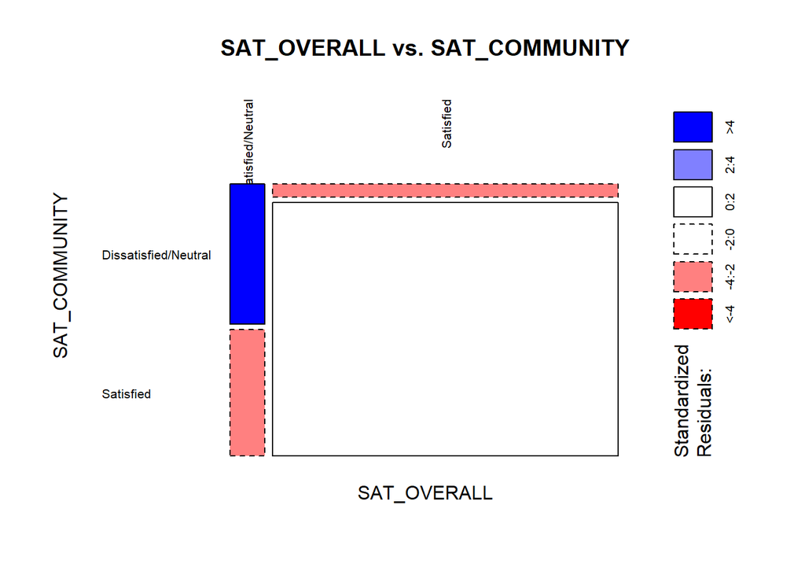

```r
mosaic(data, "SAT_OVERALL", "SAT_COMMUNITY")
```

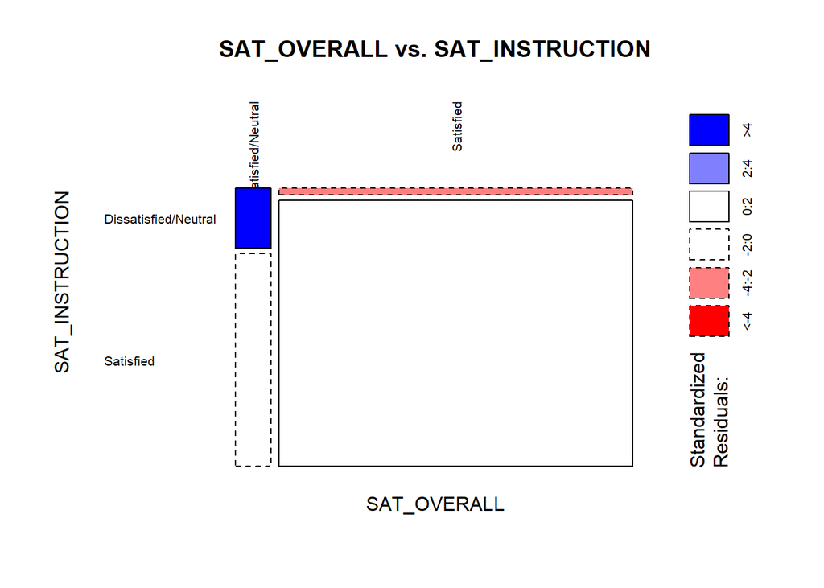

```r
mosaic(data, "SAT_OVERALL", "SAT_INSTRUCTION")
```

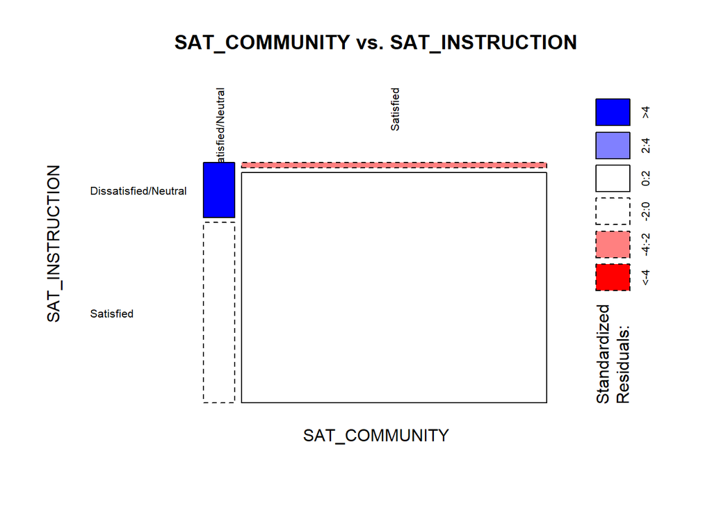

```r
mosaic(data, "SAT_COMMUNITY", "SAT_INSTRUCTION")
```

Balloon graphs for each dependent before balancing:

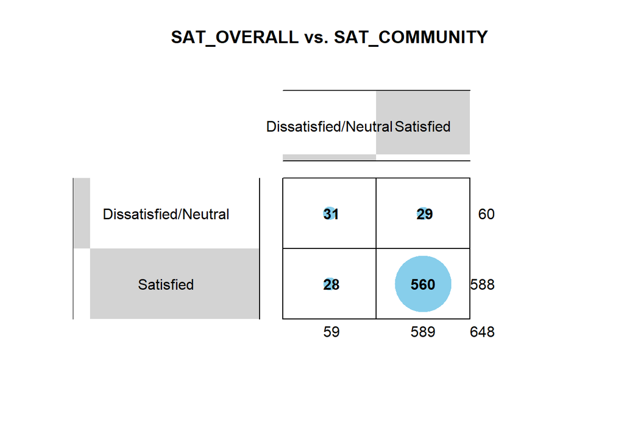

```r
balloon(data, "SAT_OVERALL", "SAT_COMMUNITY")
```

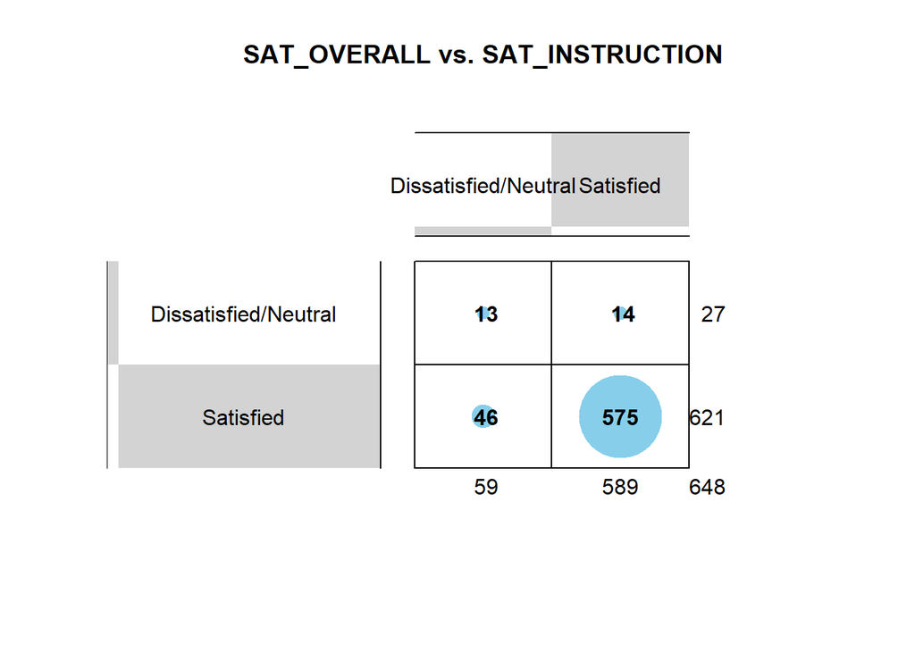

```r
balloon(data, "SAT_OVERALL", "SAT_INSTRUCTION")
```

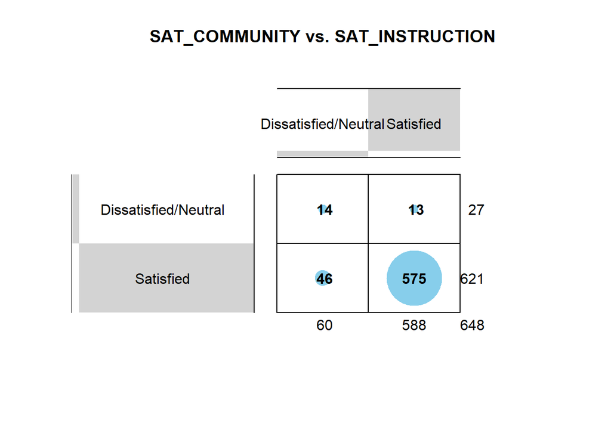

```r
balloon(data, "SAT_COMMUNITY", "SAT_INSTRUCTION")
```

Balance the data by calling the balance() funtion from the `clean.R` file. As indicated this funtion uses SMOTE sampling:

```r
data <- balance(data)
```

Category proportions for each dependent after balancing:

```r
category_proportions(data, "SAT_OVERALL")
```

```
##
## Dissatisfied/Neutral            Satisfied
##            0.4444444            0.5555556
## [1] "No. of observations: 819"
```

```r
category_proportions(data, "SAT_COMMUNITY")
```

```
##
## Dissatisfied/Neutral            Satisfied
##            0.4590965            0.5409035
## [1] "No. of observations: 819"
```

```r
category_proportions(data, "SAT_INSTRUCTION")
```

```
##
## Dissatisfied/Neutral            Satisfied
##            0.4285714            0.5714286
## [1] "No. of observations: 819"
```

Mosaic graphs for each dependent after balancing:

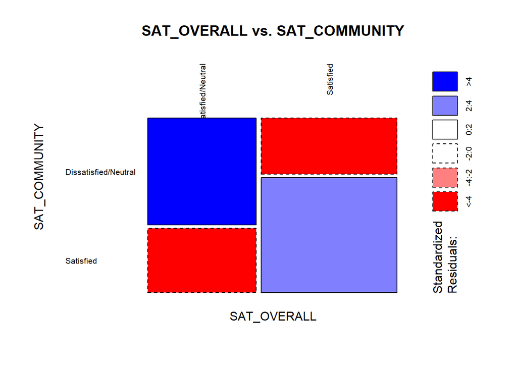

```r
mosaic(data, "SAT_OVERALL", "SAT_COMMUNITY")
```

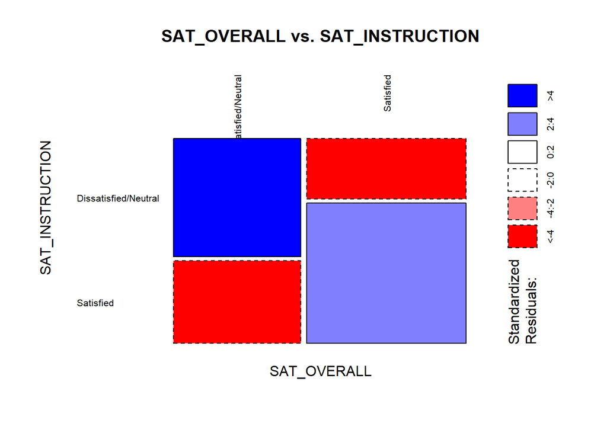

```r
mosaic(data, "SAT_OVERALL", "SAT_INSTRUCTION")
```

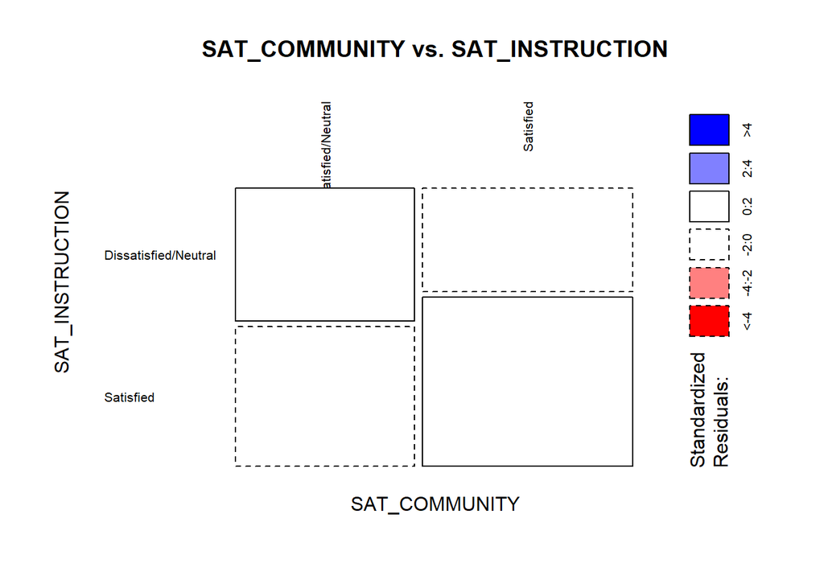

```r
mosaic(data, "SAT_COMMUNITY", "SAT_INSTRUCTION")
```

Balloon graphs for each dependent after balancing:

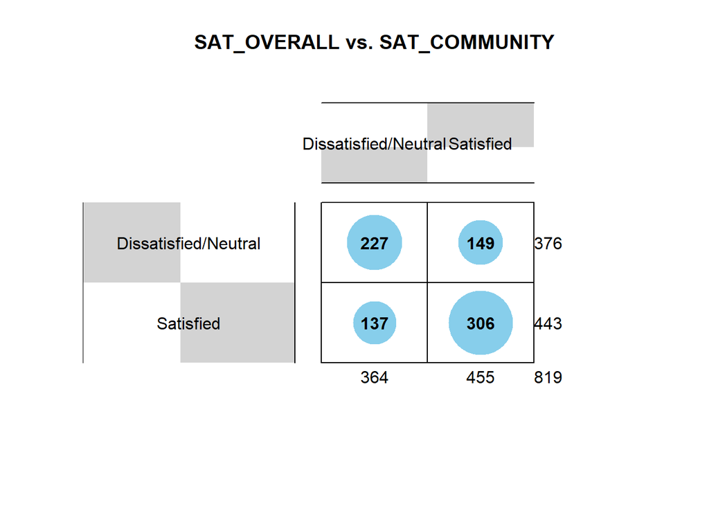

```r
balloon(data, "SAT_OVERALL", "SAT_COMMUNITY")
```

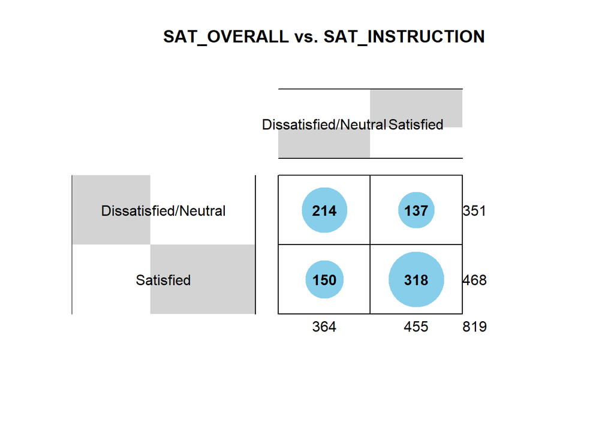

```r
balloon(data, "SAT_OVERALL", "SAT_INSTRUCTION")
```

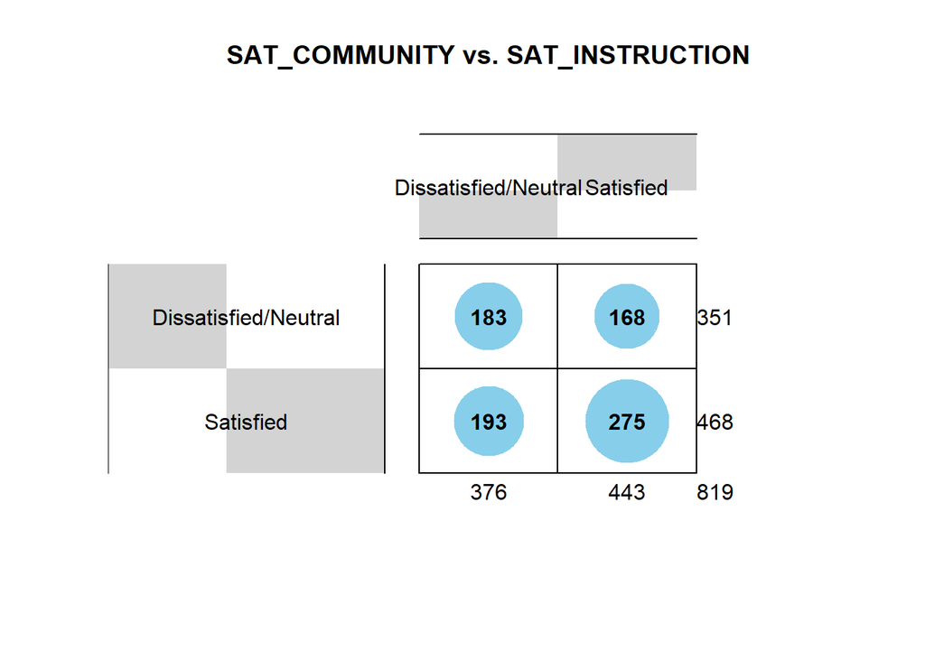

```r
balloon(data, "SAT_COMMUNITY", "SAT_INSTRUCTION")
```

These visualizations confirm a much more balanced sample.

When sampling data for our training and testing data sets, we apply stratified sampling to make sure we keep the proportions reached by the SMOTE technique while creating the two data subsets (`train` and `test`), plus the original one saved in the `full` attribute. To access the three different datasets we created (i.e. `full`, `train`, and `test`) you can access the respective elements of the `data` object as shown in the examples below.

The seperate() function is in the `clean.R` file

```r
data <- separate(data)
```

Some examples of how to interact with this object are shown below (wihtout output):

```r
nrow(data[["full"]])
nrow(data[["train"]])
nrow(data[["test"]])

head(data[["full"]])
names(data[["full"]])
summary(data[["full"]])
```

## Visualizations

Since almost all variables are categorical, we don’t have too much room to play with visualizations, but we use two main types of graphs: mosaics and correspondence analysis. Mosaic graphs allow us to visualize the conditional distributions in the data we’re analyzing, and to understand where subgroups are deviating from the implied random distributions. Correspondence analysis helps understand the relationships among the variable values. It’s similar to Principal Component Analysis (PCA) but focuses on relative rather than absolute differences, which is what we want in this case to understand relative distributions, which helps for variable selection.

For the mosaic graphs, the area of the mosaic reflects the relative magnitude of the values. Blue colors indicate observed values are higher than expected values, if the data were random. Red colors indicate observed values are lower than expected values, if the data were random.

The the correspondence analysis, all the blue values correspond to one variable, and the red ones to the other. The closer they are in the graph, the more likely they occur together in the data, and viceversa. Keep in mind that thes graphs will only be created when there are at least three categories for each of the two categorical variables used in each case. This is a requirements of the correspondence analysis.

There are lots of combinations to try, so we automate the process of creating all of the possible combinations and saving the graphs to disk so that it’s easier to go through them using the operating system’s image explorer (look for them in side the `graphs/` directory). There are interesting findings when going through those graphs.

Next we show the same information visualized using the three different mentioned techniques. It can be used to get a better sense for the data by looking at it from different points of view.

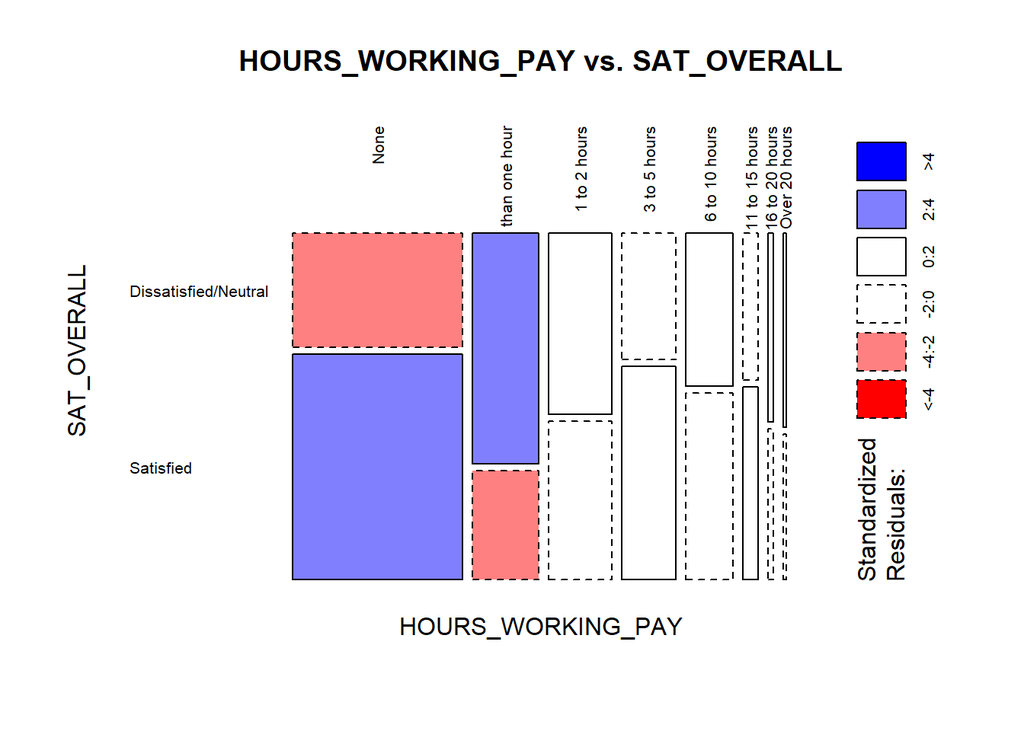

```r
mosaic(data, "HOURS_WORKING_PAY", "SAT_OVERALL")
```

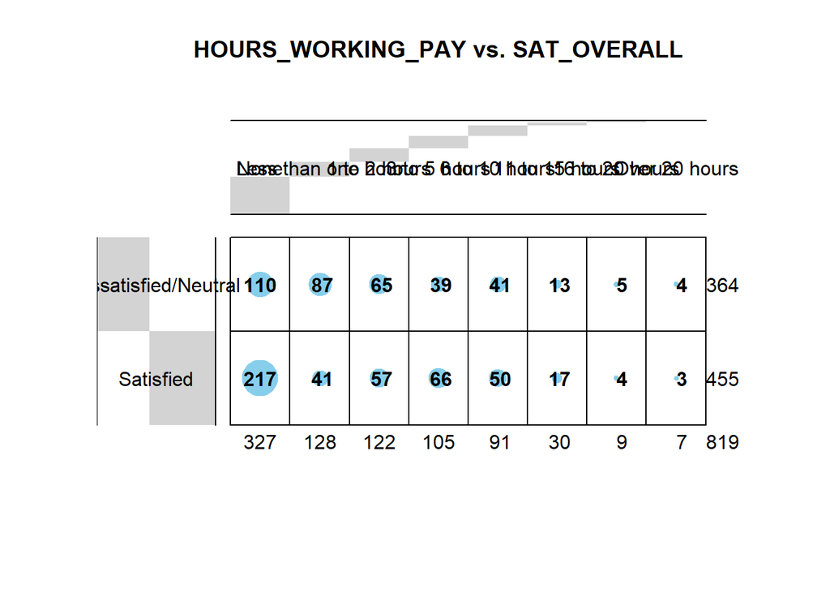

```r
balloon(data, "HOURS_WORKING_PAY", "SAT_OVERALL")
```

Correspondence analysis only makes sense when there are at least three categories in each categorical variable. This graph looks a two predictors since our dependant variables have two possible values

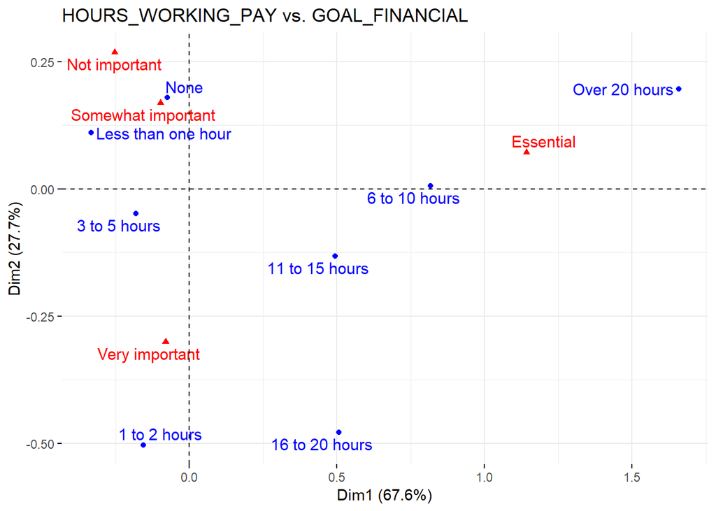

```r
correspondence(data, "HOURS_WORKING_PAY", "GOAL_FINANCIAL")
```

The following functions (from the `graph.R` file) allow you create and save visualizations for combinations you would like if the plot funtion shares the sme argument structure. in this case `(data, var1, var2)`

> **CAUTION**:Executing these lines can take a long time because there are thousands of graphs being created for each of the three types of graphs. The way this document is configured they will not be executed to avoid any accidents.

```r
create_and_save_all_graphs(data, "correspondence")
create_and_save_all_graphs(data, "balloon")
create_and_save_all_graphs(data, "mosaic")
```

## Variable selection

Variable selection is performed with Recursive Feature Elimination (RFE). The `selection_*` objects contain the following attributes: `data` which is the data with the variable selection applied, `graph` which shows the accuracy change as more variables are added, `n_variables` which is the number of variables selected, and `variables` which are the variables actually selected. Internally, Random Forests are used to measure variable importance. The Selection functions are located in the `selection.R` file.

```r
selection_overall <- variable_selection(data, "SAT_OVERALL")
```

[output not shown]

[output cut: 25 more lines]

```
##         15   0.6752 0.3021    0.03052 0.07207
##         25   0.7045 0.3697    0.02021 0.04632
##         35   0.7131 0.3897    0.01850 0.04515
##         45   0.7167 0.3981    0.02023 0.04797
##         55   0.7192 0.4052    0.02024 0.05015
##         65   0.7216 0.4109    0.00988 0.02574
##         75   0.7216 0.4115    0.02024 0.04807
##         85   0.7131 0.3933    0.02195 0.05064
##         95   0.7216 0.4117    0.02369 0.05628
##        105   0.7290 0.4277    0.02371 0.05425        *
##        115   0.7253 0.4207    0.01852 0.04445
##        124   0.7290 0.4284    0.02371 0.05738
##
## The top 5 variables (out of 105):
##    FCAREER, MCAREER, SCAREER, SRELIGION, MRELIGION
```

The selection for the “community” and “instruction” dependent variables can be accomplished with the following code (which is not actually run because it will not be used in this document, but is left as reference):

```r
selection_instruction <- variable_selection(data, "SAT_INSTRUCTION")
selection_community <- variable_selection(data, "SAT_COMMUNITY")
```

To explore the results for the selection for “overall”, you can use the following to see the filtered datasets, variables, and optimization graph. The output is not shown to preserve space, but each of those would show the first couple of rows of each dataset (train, test, and full).

```r
head(selection_overall[["data"]][["full"]])
```

|  | SAT_OVERALL | SAT_INSTRUCTION | SAT_COMMUNITY | FCAREER | MCAREER | SCAREER | SRELIGION | MRELIGION | FRELIGION | HOURS_EXERCISE_SPORTS | INCOME | HOURS_WORKING_PAY | FATHEDUC | ID | SELF_RATING_SPIRITUALITY | HOURS_STUDYING_HOMEWORK | HOURS_SOCIALIZING_WITH_FRIENDS | MOTHEDUC | HOURS_READING | SAT_Verbal | GOAL_POLITICAL_AFFAIRS | SELF_RATING_PUBLIC_SPEAKING_ABILITY | VIEW_LEGAL_SAME_SEX_MARITAL | HOURS_CLUBS_GROUPS | HOURS_HOUSE_CHILD_DUTIES | W_C | HOURS_VOLUNTEER | A | HOURS_TV | … |
| --- | --- | --- | --- | --- | --- | --- | --- | --- | --- | --- | --- | --- | --- | --- | --- | --- | --- | --- | --- | --- | --- | --- | --- | --- | --- | --- | --- | --- | --- | --- |
| 109 | Dissatisfied/Neutral | Satisfied | Dissatisfied/Neutral | Nurse | Therapist (physical, occupational, speech) | Scientific researcher | Jewish | Islamic | Eastern Orthodox | 6 to 10 hours | $200,000 to $249,999 | 1 to 2 hours | Some graduate school | 19880908 | Average | 11 to 15 hours | 3 to 5 hours | Graduate degree | 3 to 5 hours | 757 | Somewhat important | Above average | Agree strongly | 6 to 10 hours | Less than one hour | Marked | Less than one hour | Not marked | 3 to 5 hours | … |
| 596 | Satisfied | Satisfied | Dissatisfied/Neutral | Unemployed | Unemployed | Social, welfare, or recreation worker | None | None | None | Less than one hour | $10,000 to $14,999 | 6 to 10 hours | Grammar school or less | 28010052 | Below average | 3 to 5 hours | 6 to 10 hours | Grammar school or less | Less than one hour | 480 | Very important | Average | Agree strongly | 11 to 15 hours | 6 to 10 hours | Not marked | 3 to 5 hours | Not marked | 1 to 2 hours | … |
| 372 | Satisfied | Satisfied | Satisfied | Physician | Unemployed | Physician | Roman Catholic | Roman Catholic | Roman Catholic | 6 to 10 hours | $250,000 or more | None | Graduate degree | 23461242 | Above average | 6 to 10 hours | 6 to 10 hours | College degree | 1 to 2 hours | 800 | Somewhat important | Average | Agree strongly | Less than one hour | None | Marked | Less than one hour | Not marked | None | … |
| 511 | Satisfied | Satisfied | Dissatisfied/Neutral | Policymaker/Government | Interior decorator (including designer) | Undecided [student only] | United Church of Christ/Congregational | United Church of Christ/Congregational | None | 3 to 5 hours | $75,000 to $99,999 | None | Graduate degree | 19016493 | Below average | 3 to 5 hours | 6 to 10 hours | Some graduate school | Less than one hour | 630 | Somewhat important | Above average | Agree strongly | 1 to 2 hours | 1 to 2 hours | Marked | Less than one hour | Not marked | 1 to 2 hours | … |
| 415.5 | Satisfied | Satisfied | Satisfied | Business (clerical) | Other | Writer or journalist | None | None | None | 6 to 10 hours | $150,000 to $199,999 | None | Some college | 24118122 | Above average | 11 to 15 hours | 6 to 10 hours | Some college | 3 to 5 hours | 670 | Somewhat important | Highest 10% | Agree strongly | 3 to 5 hours | None | Marked | 1 to 2 hours | Not marked | Less than one hour | … |
| 580 | Dissatisfied/Neutral | Satisfied | Satisfied | Teacher or administrator (secondary) | Homemaker (full-time) | Undecided [student only] | Buddhist | Other Religion | Other Religion | 1 to 2 hours | $100,000 to $149,999 | Less than one hour | Graduate degree | 27925212 | Above average | 1 to 2 hours | 3 to 5 hours | Graduate degree | 1 to 2 hours | 700 | Not important | Above average | Agree strongly | 3 to 5 hours | Less than one hour | Marked | Less than one hour | Not marked | 1 to 2 hours | … |

```r
head(selection_overall[["data"]][["train"]])
```

|  | SAT_OVERALL | SAT_INSTRUCTION | SAT_COMMUNITY | FCAREER | MCAREER | SCAREER | SRELIGION | MRELIGION | FRELIGION | HOURS_EXERCISE_SPORTS | INCOME | HOURS_WORKING_PAY | FATHEDUC | ID | SELF_RATING_SPIRITUALITY | HOURS_STUDYING_HOMEWORK | HOURS_SOCIALIZING_WITH_FRIENDS | MOTHEDUC | HOURS_READING | SAT_Verbal | GOAL_POLITICAL_AFFAIRS | SELF_RATING_PUBLIC_SPEAKING_ABILITY | VIEW_LEGAL_SAME_SEX_MARITAL | HOURS_CLUBS_GROUPS | HOURS_HOUSE_CHILD_DUTIES | W_C | HOURS_VOLUNTEER | A | HOURS_TV | … |
| --- | --- | --- | --- | --- | --- | --- | --- | --- | --- | --- | --- | --- | --- | --- | --- | --- | --- | --- | --- | --- | --- | --- | --- | --- | --- | --- | --- | --- | --- | --- |
| 372 | Satisfied | Satisfied | Satisfied | Physician | Unemployed | Physician | Roman Catholic | Roman Catholic | Roman Catholic | 6 to 10 hours | $250,000 or more | None | Graduate degree | 23461242 | Above average | 6 to 10 hours | 6 to 10 hours | College degree | 1 to 2 hours | 800 | Somewhat important | Average | Agree strongly | Less than one hour | None | Marked | Less than one hour | Not marked | None | … |
| 415.5 | Satisfied | Satisfied | Satisfied | Business (clerical) | Other | Writer or journalist | None | None | None | 6 to 10 hours | $150,000 to $199,999 | None | Some college | 24118122 | Above average | 11 to 15 hours | 6 to 10 hours | Some college | 3 to 5 hours | 670 | Somewhat important | Highest 10% | Agree strongly | 3 to 5 hours | None | Marked | 1 to 2 hours | Not marked | Less than one hour | … |
| 580 | Dissatisfied/Neutral | Satisfied | Satisfied | Teacher or administrator (secondary) | Homemaker (full-time) | Undecided [student only] | Buddhist | Other Religion | Other Religion | 1 to 2 hours | $100,000 to $149,999 | Less than one hour | Graduate degree | 27925212 | Above average | 1 to 2 hours | 3 to 5 hours | Graduate degree | 1 to 2 hours | 700 | Not important | Above average | Agree strongly | 3 to 5 hours | Less than one hour | Marked | Less than one hour | Not marked | 1 to 2 hours | … |
| 554.1 | Satisfied | Satisfied | Satisfied | Conservationist or forester | Lawyer (attorney) or judge | Therapist (physical, occupational, speech) | None | None | None | Over 20 hours | $150,000 to $199,999 | None | Graduate degree | 27760572 | Lowest 10% | 11 to 15 hours | 6 to 10 hours | Graduate degree | 1 to 2 hours | 740 | Very important | Average | Agree strongly | None | 1 to 2 hours | Marked | Less than one hour | Not marked | None | … |
| 1871 | Dissatisfied/Neutral | Satisfied | Dissatisfied/Neutral | Engineer | School principal or superintendent | Veterinarian | Roman Catholic | Presbyterian | Methodist | 1 to 2 hours | $100,000 to $149,999 | 1 to 2 hours | Graduate degree | 5529023 | Below average | 1 to 2 hours | 6 to 10 hours | Graduate degree | 1 to 2 hours | 738 | Somewhat important | Average | Agree strongly | 3 to 5 hours | 1 to 2 hours | Marked | Less than one hour | Not marked | 1 to 2 hours | … |
| 252 | Dissatisfied/Neutral | Satisfied | Dissatisfied/Neutral | Interior decorator (including designer) | Lab technician or hygienist | Other | LDS (Mormon) | Islamic | Other Religion | 6 to 10 hours | $75,000 to $99,999 | None | Graduate degree | 5848619 | Below average | 3 to 5 hours | 6 to 10 hours | Graduate degree | 1 to 2 hours | 677 | Not important | Below average | Agree strongly | Less than one hour | Less than one hour | Marked | 3 to 5 hours | Not marked | 3 to 5 hours | … |

```r
head(selection_overall[["data"]][["test"]])
```

|  | SAT_OVERALL | SAT_INSTRUCTION | SAT_COMMUNITY | FCAREER | MCAREER | SCAREER | SRELIGION | MRELIGION | FRELIGION | HOURS_EXERCISE_SPORTS | INCOME | HOURS_WORKING_PAY | FATHEDUC | ID | SELF_RATING_SPIRITUALITY | HOURS_STUDYING_HOMEWORK | HOURS_SOCIALIZING_WITH_FRIENDS | MOTHEDUC | HOURS_READING | SAT_Verbal | GOAL_POLITICAL_AFFAIRS | SELF_RATING_PUBLIC_SPEAKING_ABILITY | VIEW_LEGAL_SAME_SEX_MARITAL | HOURS_CLUBS_GROUPS | HOURS_HOUSE_CHILD_DUTIES | W_C | HOURS_VOLUNTEER | A | HOURS_TV | … |
| --- | --- | --- | --- | --- | --- | --- | --- | --- | --- | --- | --- | --- | --- | --- | --- | --- | --- | --- | --- | --- | --- | --- | --- | --- | --- | --- | --- | --- | --- | --- |
| 109 | Dissatisfied/Neutral | Satisfied | Dissatisfied/Neutral | Nurse | Therapist (physical, occupational, speech) | Scientific researcher | Jewish | Islamic | Eastern Orthodox | 6 to 10 hours | $200,000 to $249,999 | 1 to 2 hours | Some graduate school | 19880908 | Average | 11 to 15 hours | 3 to 5 hours | Graduate degree | 3 to 5 hours | 757 | Somewhat important | Above average | Agree strongly | 6 to 10 hours | Less than one hour | Marked | Less than one hour | Not marked | 3 to 5 hours | … |
| 596 | Satisfied | Satisfied | Dissatisfied/Neutral | Unemployed | Unemployed | Social, welfare, or recreation worker | None | None | None | Less than one hour | $10,000 to $14,999 | 6 to 10 hours | Grammar school or less | 28010052 | Below average | 3 to 5 hours | 6 to 10 hours | Grammar school or less | Less than one hour | 480 | Very important | Average | Agree strongly | 11 to 15 hours | 6 to 10 hours | Not marked | 3 to 5 hours | Not marked | 1 to 2 hours | … |
| 511 | Satisfied | Satisfied | Dissatisfied/Neutral | Policymaker/Government | Interior decorator (including designer) | Undecided [student only] | United Church of Christ/Congregational | United Church of Christ/Congregational | None | 3 to 5 hours | $75,000 to $99,999 | None | Graduate degree | 19016493 | Below average | 3 to 5 hours | 6 to 10 hours | Some graduate school | Less than one hour | 630 | Somewhat important | Above average | Agree strongly | 1 to 2 hours | 1 to 2 hours | Marked | Less than one hour | Not marked | 1 to 2 hours | … |
| 1113 | Satisfied | Satisfied | Dissatisfied/Neutral | Law enforcement officer | Law enforcement officer | Unemployed | LDS (Mormon) | LDS (Mormon) | Other Religion | 3 to 5 hours | $75,000 to $99,999 | Less than one hour | Some graduate school | 4733585 | Average | 6 to 10 hours | 6 to 10 hours | Some graduate school | 1 to 2 hours | 665 | Not important | Below average | Agree strongly | Less than one hour | Less than one hour | Marked | 3 to 5 hours | Not marked | 3 to 5 hours | … |
| 227.1 | Dissatisfied/Neutral | Satisfied | Satisfied | College teacher | Teacher or administrator (secondary) | Scientific researcher | None | None | None | 6 to 10 hours | $50,000 to $59,999 | None | Graduate degree | 17049900 | Below average | Less than one hour | 16 to 20 hours | College degree | None | 800 | Very important | Below average | Agree somewhat | None | Less than one hour | Marked | None | Not marked | None | … |
| 622.1 | Satisfied | Satisfied | Dissatisfied/Neutral | Engineer | Teacher or administrator (elementary) | Physician | Roman Catholic | Roman Catholic | None | 16 to 20 hours | $200,000 to $249,999 | 1 to 2 hours | Graduate degree | 28174860 | Below average | 11 to 15 hours | 3 to 5 hours | Graduate degree | Less than one hour | 690 | Somewhat important | Below average | Agree strongly | 1 to 2 hours | Less than one hour | Marked | 3 to 5 hours | Not marked | 1 to 2 hours | … |

To see the variables found to be with the most predictive power, we can use the following code, which shows the number of variables and the variable names themselves.

```r
selection_overall[["n_variables"]]
```

```
## [1] 105
```

```r
selection_overall[["variables"]]
```

```
##   [1] "FCAREER"
##   [2] "MCAREER"
##   [3] "SCAREER"
##   [4] "SRELIGION"
##   [5] "MRELIGION"
##   [6] "FRELIGION"
##   [7] "HOURS_EXERCISE_SPORTS"
##   [8] "INCOME"
##   [9] "HOURS_WORKING_PAY"
##  [10] "FATHEDUC"
##  [11] "ID"
##  [12] "SELF_RATING_SPIRITUALITY"
##  [13] "HOURS_STUDYING_HOMEWORK"
##  [14] "HOURS_SOCIALIZING_WITH_FRIENDS"
##  [15] "MOTHEDUC"
```

[output cut: 90 more lines]

To see a graph of how the predictive accuracy changes as we add more variables, we can look at the following graph. The filled dot corresponds to the selected case.

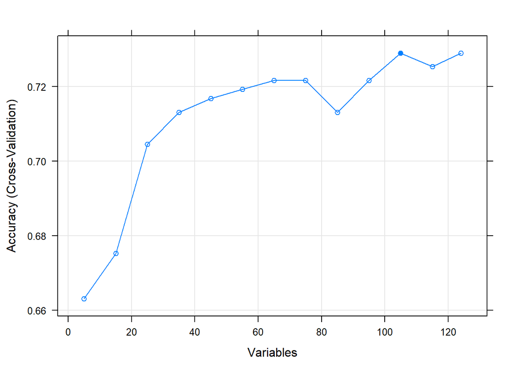

```r
selection_overall[["graph"]]
```

## Model application

> *Our model application becomes problematic because there is a very low number of observations per year for some samples. To avoid the problem, I’m currently setting the `YEAR_FS` value to `ALL` for all observations (essentially removing ‘year of CSS survey’ from the model) we can relax this later to test what recategorization makes more sense.*

```r
val <- "ALL"
var <- "YEAR_FS"
data <- recode_variable(data, var, val)
selection_overall[["data"]] <- recode_variable(
    selection_overall[["data"]], var, val
)
```

The same goes for the other dependents (which we are not using in this document, so their code will not be executed).

```r
selection_community[["data"]] <- recode_variable(
    selection_community[["data"]], var, val
)
selection_instruction[["data"]] <- recode_variable(
    selection_instruction[["data"]], var, val
)
```

To specify which models we want to use we use the following. The first string (e.g. “random_forest”) is an identifier created by us to know what model we’re working with, and the second string (e.g. “rf”) is an ID for the model we want to use that is recognized by the `caret` package. Feel free to add other models, you can find the full list here: https://topepo.github.io/caret/available-models.html

> These models depend on external packages. If you don’t have installed in your system, when you execute the code, you’ll be notified that you don’t have them, and you’ll be asked whether you want to install them. If you do, execution will continue normally after the corresponding installations.

```r
models <- list(
    "random_forest" = "rf",
    "support_vector_machine" = "svmRadial",
    "naive_bayes" = "naive_bayes"
)
```

We now proceed to find the best model for each year with cross-validation (calling the CV function frome the `train.R` file):

```r
overall_results <- best_results_per_year(
    selection_overall[["data"]],
    "SAT_OVERALL",
    models
)
```

```
## [1] "- ALL"
## [1] "    - random_forest"
## [1] "    - support_vector_machine"
```

```
## [1] "    - naive_bayes"
```

To accomplish the same for the other dependents, we can use the following code, which is not actually executed in this blog as we focus on overall satisfaction.

```r
community_results <- best_results_per_year(
    selection_community[["data"]],
    "SAT_COMMUNITY",
    models
)
instruction_results <- best_results_per_year(
    selection_instruction[["data"]],
    "SAT_INSTRUCTION",
    models
)
```

## Results

To compare the predictive power, you may want to look at the predictive power of each model and each dependent variable. You can find these values in the `metrics` attribute in each case.

Note that in some cases there may be no variable importance information (it depends on whether or not the model used is able to produce it), and there may also not be a ROC curve to show (in the case were the sample did not have at least one case for one of the categories). To fix this last case we would have to use stratified-sampling.

> The follwing script included year which would be valuable exploration accross years. However, year has been collapsed to ‘ALL’ to effectively remove year from the model.

Years available:

```r
names(overall_results)
```

```
## [1] "Y_ALL"
```

Models available:

```r
names(overall_results[["Y_ALL"]])
```

```
## [1] "random_forest"          "support_vector_machine"
## [3] "naive_bayes"
```

Result objects available for model selection:

```r
names(overall_results[["Y_ALL"]][["random_forest"]])
```

```
## [1] "metrics"    "graph"      "predictor"  "importance"
```

See the `predictor` object, for Random Forest:

```r
overall_results[["Y_ALL"]][["random_forest"]][["predictor"]]
```

```
## Random Forest
##
## 574 samples
## 103 predictors
##   2 classes: 'Dissatisfied/Neutral', 'Satisfied'
##
## No pre-processing
## Resampling: Cross-Validated (3 fold)
## Summary of sample sizes: 383, 383, 382
## Addtional sampling using SMOTE
##
## Resampling results across tuning parameters:
##
##   mtry  Accuracy   Kappa
##     2   0.6306446  0.1880562
##    32   0.7612802  0.5049863
##   525   0.7334206  0.4501814
##
## Accuracy was used to select the optimal model using the largest value.
## The final value used for the model was mtry = 32.
```

```r
overall_results[["Y_ALL"]][["support_vector_machine"]][["metrics"]]
```

```
## Confusion Matrix and Statistics
##
##                       Reference
## Prediction             Dissatisfied/Neutral Satisfied
##   Dissatisfied/Neutral                   61        23
##   Satisfied                              48       113
##
##                Accuracy : 0.7102
##                  95% CI : (0.649, 0.7662)
##     No Information Rate : 0.5551
##     P-Value [Acc > NIR] : 4.42e-07
##
##                   Kappa : 0.3996
##  Mcnemar's Test P-Value : 0.004396
##
##             Sensitivity : 0.5596
##             Specificity : 0.8309
##          Pos Pred Value : 0.7262
##          Neg Pred Value : 0.7019
##              Prevalence : 0.4449
##          Detection Rate : 0.2490
##    Detection Prevalence : 0.3429
##       Balanced Accuracy : 0.6953
##
##        'Positive' Class : Dissatisfied/Neutral
##
```

```r
overall_results[["Y_ALL"]][["random_forest"]][["metrics"]]
```

```
## Confusion Matrix and Statistics
##
##                       Reference
## Prediction             Dissatisfied/Neutral Satisfied
##   Dissatisfied/Neutral                   73        15
##   Satisfied                              36       121
##
##                Accuracy : 0.7918
##                  95% CI : (0.7356, 0.8409)
##     No Information Rate : 0.5551
##     P-Value [Acc > NIR] : 7.276e-15
##
##                   Kappa : 0.5703
##  Mcnemar's Test P-Value : 0.005101
##
##             Sensitivity : 0.6697
##             Specificity : 0.8897
##          Pos Pred Value : 0.8295
##          Neg Pred Value : 0.7707
##              Prevalence : 0.4449
##          Detection Rate : 0.2980
##    Detection Prevalence : 0.3592
##       Balanced Accuracy : 0.7797
##
##        'Positive' Class : Dissatisfied/Neutral
##
```

```r
overall_results[["Y_ALL"]][["naive_bayes"]][["metrics"]]
```

```
## Confusion Matrix and Statistics
##
##                       Reference
## Prediction             Dissatisfied/Neutral Satisfied
##   Dissatisfied/Neutral                   25         8
##   Satisfied                              84       128
##
##                Accuracy : 0.6245
##                  95% CI : (0.5606, 0.6853)
##     No Information Rate : 0.5551
##     P-Value [Acc > NIR] : 0.01649
##
##                   Kappa : 0.1832
##  Mcnemar's Test P-Value : 5.312e-15
##
##             Sensitivity : 0.2294
##             Specificity : 0.9412
##          Pos Pred Value : 0.7576
##          Neg Pred Value : 0.6038
##              Prevalence : 0.4449
##          Detection Rate : 0.1020
##    Detection Prevalence : 0.1347
##       Balanced Accuracy : 0.5853
##
##        'Positive' Class : Dissatisfied/Neutral
##
```

See the “optimization” `graph`, for Random Forest:

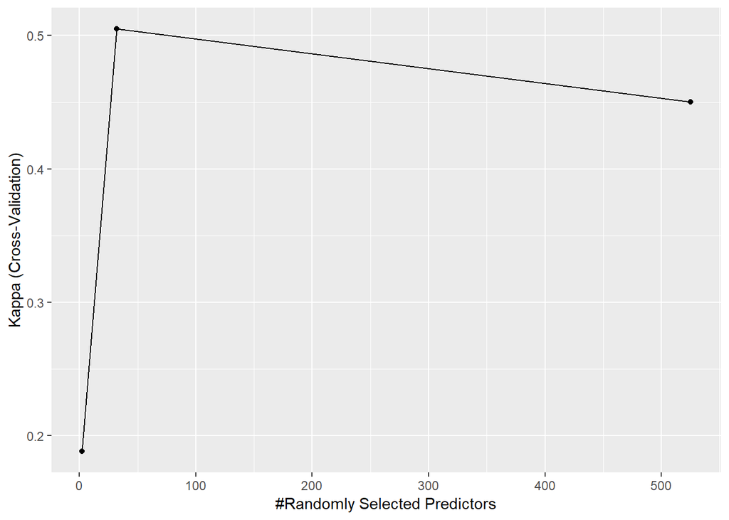

```r
overall_results[["Y_ALL"]][["random_forest"]][["graph"]]
```

See the “variable” `importance`, for a given Random Forest (from these three models, only Random Forests provide `importance`):

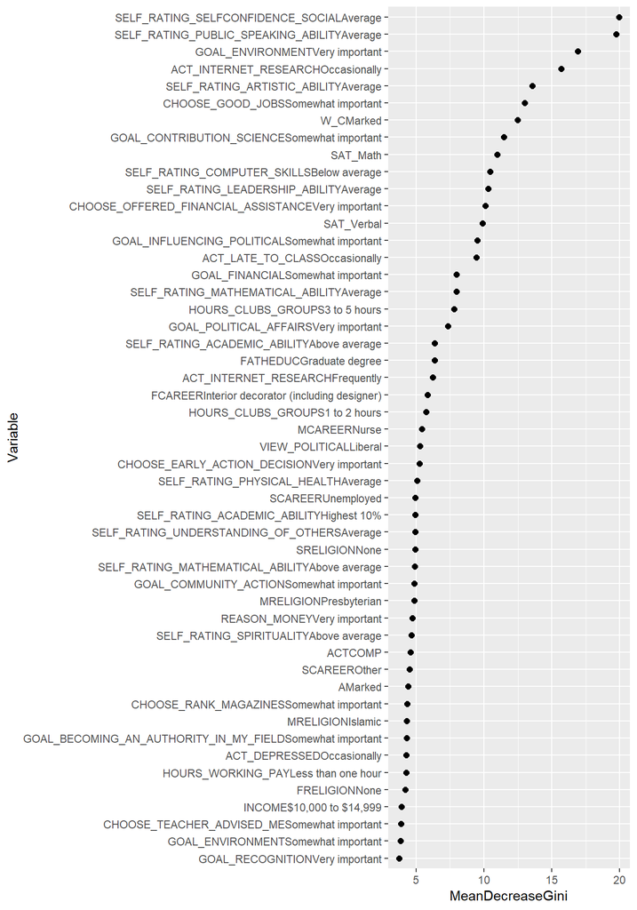

```r
overall_results[["Y_ALL"]][["random_forest"]][["importance"]]
```

See the “test” data set `roc`, for our Random Forest model:

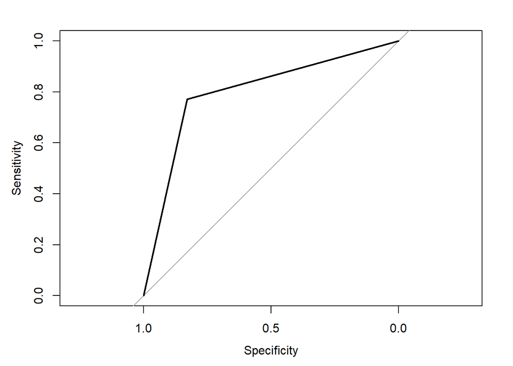

```
##
## Call:
## plot.roc.default(x = as.numeric(predictions), predictor = as.numeric(data[,     dependent]))
##
## Data: as.numeric(data[, dependent]) in 88 controls (as.numeric(predictions) 1) < 157 cases (as.numeric(predictions) 2).
## Area under the curve: 0.8001
```

```r
predictor <- overall_results[["Y_ALL"]][["random_forest"]][["predictor"]]
roc(predictor, data[["test"]], "SAT_OVERALL")
```

The results I’m seeing on average are following. Note that these may be different every time you run the analysis because we’re not controlling the “seed” for the randomized algorithms (this is done on purpose to see varied results, but for publishing or sharing results, we would control the seed).

| Model | Accuracy | Kappa |
| --- | --- | --- |
| Support Vector Machine | 0.6637 | 0.3274 |
| Random Forest | 0.7876 | 0.5752 |
| Naive Bayes | 0.6327 | 0.2655 |

## Discusssion

The data collection has been imporoving and the quality and response rate improves with each survey cycle. THe current model (with much polishing and tuning) may give insight into admissions and intrusive advising practices,e.g. targeting interventions at freshman groups predicted less likely to be satisfied. As the sample size and data quality improve it seems likely that models can be improved by adding variation accross time.